# Data Investigation Project:

## Analysis and Insights of the top 10 growth countries during the 1st decade of the 21st century

Introduction

Data Wrangling

- Gather
- Pre-Assesing
- Assess
- Clean

Exploratory Data Analysis

- 01. Top10 Countries GDP Growth
- 02. Top10 Countries GDP
- 03. Education Expenditure
- 04. Health spending per person

Conclusions

## Introduction

> - Using the World Bank Data of different aspects of countries. I will filter out this list of 192 countries to the top 10 countries that achieved the top average growth over the first decade of the 21st century and will ist them descendingly based on each country's average growth. Then I'll pick up three main representing numbers namely **GDP, Education Expenditure, and Health Spending per person** as there is no development plan of any country not look/consider these expenditures out of their impacts on the overall country economy performance. Thereafter, will analyze these numbers' effects on four important dependent metrics **Income-Per_Person, CO2-Emission, Human-Development_index(HDI), and Life-Expectancy**. Will examine my data set and answer some questions like:

>   ```
>   - Did the GDP growth was steady or fluctuated for each country?.
>   - Did these countries' nationals find any change in their own wealth?
>   - Did these countries show any attention toward our planet's top issue, global warming?
>   - Did countries invest more in developing their peoples?
>   - Did they have any vision regarding their health sector?
>   ```

>   Finally, I'll conclude my insights and analysis results of the selected data for the mentioned countries.

```python
import pandas as pd
import numpy as np
import seaborn as sns
import matplotlib.pyplot as pyplt
import matplotlib as mplt
%matplotlib inline
pd.options.display.max_colwidth=1000
pd.options.display.max_rows=None
pd.options.display.max_columns=None
pd.options.display.precision=3
```

# Data Wrangling

## Gather

```python
#loading the file of "GDP-Growth" into data frame
df_growth=pd.read_csv('gdp_total_yearly_growth.csv')
df_growth.sample(2)
```

|  | country | 1801 | 1802 | 1803 | 1804 | 1805 | 1806 | 1807 | 1808 | 1809 | 1810 | 1811 | 1812 | 1813 | 1814 | 1815 | 1816 | 1817 | 1818 | 1819 | 1820 | 1821 | 1822 | 1823 | 1824 | 1825 | 1826 | 1827 | 1828 | … |
| --- | --- | --- | --- | --- | --- | --- | --- | --- | --- | --- | --- | --- | --- | --- | --- | --- | --- | --- | --- | --- | --- | --- | --- | --- | --- | --- | --- | --- | --- | --- |
| 65 | Ghana | 0.065 | 0.065 | 0.065 | 0.065 | 0.065 | 0.065 | 0.065 | 0.065 | 0.065 | 0.065 | 0.065 | 0.065 | 0.065 | 0.065 | 0.065 | 0.065 | 0.065 | 0.065 | 0.065 | 0.065 | -0.423 | -0.423 | -0.423 | -0.423 | -0.423 | -0.423 | -0.423 | -0.423 | … |
| 146 | Sao Tome and Principe | 0.171 | 0.171 | 0.171 | 0.171 | 0.171 | 0.171 | 0.171 | 0.171 | 0.171 | 0.171 | 0.171 | 0.171 | 0.171 | 0.171 | 0.171 | 0.171 | 0.171 | 0.171 | 0.171 | 0.171 | 0.920 | 0.923 | 0.922 | 0.920 | 0.923 | 0.918 | 0.925 | 0.919 | … |

```python
# load the file of "Total-GDP" into data frame
df_gdp= pd.read_csv('total_gdp_ppp_inflation_adjusted.csv')
df_gdp.sample(2)
```

|  | country | 1800 | 1801 | 1802 | 1803 | 1804 | 1805 | 1806 | 1807 | 1808 | 1809 | 1810 | 1811 | 1812 | 1813 | 1814 | 1815 | 1816 | 1817 | 1818 | 1819 | 1820 | 1821 | 1822 | 1823 | 1824 | 1825 | 1826 | 1827 | … |
| --- | --- | --- | --- | --- | --- | --- | --- | --- | --- | --- | --- | --- | --- | --- | --- | --- | --- | --- | --- | --- | --- | --- | --- | --- | --- | --- | --- | --- | --- | --- |
| 83 | Jamaica | 6.590e+08 | 6.590e+08 | 6.590e+08 | 6.590e+08 | 6.590e+08 | 6.590e+08 | 6.590e+08 | 6.590e+08 | 6.590e+08 | 6.590e+08 | 6.590e+08 | 6.590e+08 | 6.590e+08 | 6.590e+08 | 6.590e+08 | 6.590e+08 | 6.590e+08 | 6.590e+08 | 6.590e+08 | 6.590e+08 | 6.590e+08 | 6.540e+08 | 6.480e+08 | 6.430e+08 | 6.370e+08 | 6.320e+08 | 6.260e+08 | 6.210e+08 | … |
| 79 | Iraq | 1.170e+09 | 1.170e+09 | 1.170e+09 | 1.170e+09 | 1.170e+09 | 1.180e+09 | 1.180e+09 | 1.180e+09 | 1.180e+09 | 1.180e+09 | 1.180e+09 | 1.180e+09 | 1.180e+09 | 1.180e+09 | 1.180e+09 | 1.180e+09 | 1.190e+09 | 1.190e+09 | 1.190e+09 | 1.190e+09 | 1.190e+09 | 1.200e+09 | 1.220e+09 | 1.230e+09 | 1.240e+09 | 1.260e+09 | 1.270e+09 | 1.290e+09 | … |

```python
# load the file of "Income per person" into data frame
df_income= pd.read_csv('income_per_person_gdppercapita_ppp_inflation_adjusted.csv')
df_income.sample(2)
```

|  | country | 1800 | 1801 | 1802 | 1803 | 1804 | 1805 | 1806 | 1807 | 1808 | 1809 | 1810 | 1811 | 1812 | 1813 | 1814 | 1815 | 1816 | 1817 | 1818 | 1819 | 1820 | 1821 | 1822 | 1823 | 1824 | 1825 | 1826 | 1827 | … |
| --- | --- | --- | --- | --- | --- | --- | --- | --- | --- | --- | --- | --- | --- | --- | --- | --- | --- | --- | --- | --- | --- | --- | --- | --- | --- | --- | --- | --- | --- | --- |
| 146 | Saudi Arabia | 2370 | 2370 | 2370 | 2370 | 2370 | 2370 | 2370 | 2380 | 2380 | 2380 | 2380 | 2380 | 2390 | 2390 | 2390 | 2390 | 2390 | 2390 | 2390 | 2400 | 2400 | 2400 | 2400 | 2410 | 2410 | 2410 | 2410 | 2410 | … |
| 43 | Cuba | 902 | 909 | 917 | 925 | 932 | 940 | 948 | 956 | 964 | 972 | 980 | 988 | 996 | 1010 | 1010 | 1020 | 1030 | 1040 | 1050 | 1060 | 1070 | 1070 | 1080 | 1090 | 1100 | 1110 | 1120 | 1130 | … |

```python
# load the file of "CO2 emissions" into data frame
df_co2= pd.read_csv('yearly_co2_emissions_1000_tonnes.csv')
df_co2.sample(2)
```

|  | country | 1751 | 1752 | 1753 | 1754 | 1755 | 1756 | 1757 | 1758 | 1759 | 1760 | 1761 | 1762 | 1763 | 1764 | 1765 | 1766 | 1767 | 1768 | 1769 | 1770 | 1771 | 1772 | 1773 | 1774 | 1775 | 1776 | 1777 | 1778 | … |
| --- | --- | --- | --- | --- | --- | --- | --- | --- | --- | --- | --- | --- | --- | --- | --- | --- | --- | --- | --- | --- | --- | --- | --- | --- | --- | --- | --- | --- | --- | --- |
| 42 | Croatia | NaN | NaN | NaN | NaN | NaN | NaN | NaN | NaN | NaN | NaN | NaN | NaN | NaN | NaN | NaN | NaN | NaN | NaN | NaN | NaN | NaN | NaN | NaN | NaN | NaN | NaN | NaN | NaN | … |
| 21 | Bosnia and Herzegovina | NaN | NaN | NaN | NaN | NaN | NaN | NaN | NaN | NaN | NaN | NaN | NaN | NaN | NaN | NaN | NaN | NaN | NaN | NaN | NaN | NaN | NaN | NaN | NaN | NaN | NaN | NaN | NaN | … |

```python
# load the file of "Education expindutre" into data frame
df_edu_spend= pd.read_csv('education_expenditure(current US$).csv')
df_edu_spend.sample(2)
```

|  | country | 1970 | 1971 | 1972 | 1973 | 1974 | 1975 | 1976 | 1977 | 1978 | 1979 | 1980 | 1981 | 1982 | 1983 | 1984 | 1985 | 1986 | 1987 | 1988 | 1989 | 1990 | 1991 | 1992 | 1993 | 1994 | 1995 | 1996 | 1997 | … |
| --- | --- | --- | --- | --- | --- | --- | --- | --- | --- | --- | --- | --- | --- | --- | --- | --- | --- | --- | --- | --- | --- | --- | --- | --- | --- | --- | --- | --- | --- | --- |
| 14 | Belarus | NaN | NaN | NaN | NaN | NaN | NaN | NaN | NaN | NaN | NaN | NaN | NaN | NaN | NaN | NaN | NaN | NaN | NaN | NaN | NaN | 7.790e+08 | 7.740e+08 | 8.690e+08 | 8.300e+08 | 8.160e+08 | 7.230e+08 | 6.770e+08 | 7.560e+08 | … |
| 6 | Armenia | NaN | NaN | NaN | NaN | NaN | NaN | NaN | NaN | NaN | NaN | NaN | NaN | NaN | NaN | NaN | NaN | NaN | NaN | NaN | NaN | 7.610e+07 | 7.230e+07 | 3.720e+07 | 4.190e+07 | 3.500e+07 | 4.050e+07 | 2.790e+07 | 3.190e+07 | … |

```python
# load the file of "HDI" into data frame
df_hdi= pd.read_csv('hdi_human_development_index.csv')
df_hdi.sample(2)
```

|  | country | 1990 | 1991 | 1992 | 1993 | 1994 | 1995 | 1996 | 1997 | 1998 | 1999 | 2000 | 2001 | 2002 | 2003 | 2004 | 2005 | 2006 | 2007 | 2008 | 2009 | 2010 | 2011 | 2012 | 2013 | 2014 | 2015 | 2016 | 2017 | … |
| --- | --- | --- | --- | --- | --- | --- | --- | --- | --- | --- | --- | --- | --- | --- | --- | --- | --- | --- | --- | --- | --- | --- | --- | --- | --- | --- | --- | --- | --- | --- |
| 142 | Sao Tome and Principe | 0.437 | 0.438 | 0.441 | 0.444 | 0.449 | 0.452 | 0.458 | 0.462 | 0.467 | 0.474 | 0.480 | 0.489 | 0.494 | 0.502 | 0.509 | 0.517 | 0.526 | 0.531 | 0.532 | 0.541 | 0.546 | 0.553 | 0.558 | 0.568 | 0.577 | 0.590 | 0.593 | 0.603 | … |
| 26 | Burkina Faso | NaN | NaN | NaN | NaN | NaN | NaN | NaN | NaN | NaN | NaN | 0.286 | 0.290 | 0.296 | 0.303 | 0.312 | 0.324 | 0.333 | 0.344 | 0.357 | 0.366 | 0.375 | 0.385 | 0.394 | 0.401 | 0.405 | 0.413 | 0.420 | 0.429 | … |

```python
# load the file of "Health spending per person" into data frame
df_hlth_spend= pd.read_csv('total_health_spending_per_person_us.csv')
df_hlth_spend.sample(2)
```

|  | country | 1995 | 1996 | 1997 | 1998 | 1999 | 2000 | 2001 | 2002 | 2003 | 2004 | 2005 | 2006 | 2007 | 2008 | 2009 | 2010 |
| --- | --- | --- | --- | --- | --- | --- | --- | --- | --- | --- | --- | --- | --- | --- | --- | --- | --- |
| 157 | St. Lucia | 181.0 | 209.0 | 199.0 | 215.0 | 224.0 | 231.0 | 245.0 | 254.0 | 268.0 | 282.0 | 311.0 | 406.0 | 411.0 | 468.0 | 467.0 | 465.0 |
| 150 | Solomon Islands | 47.3 | 46.6 | 49.5 | 43.0 | 46.1 | 48.4 | 61.3 | 48.0 | 45.9 | 46.5 | 72.3 | 63.6 | 69.1 | 72.2 | 102.0 | 107.0 |

```python
# load the file of "Life Expectancy" into data frame
df_life_expct= pd.read_csv('life_expectancy_years.csv')
df_life_expct.sample(2)
```

|  | country | 1800 | 1801 | 1802 | 1803 | 1804 | 1805 | 1806 | 1807 | 1808 | 1809 | 1810 | 1811 | 1812 | 1813 | 1814 | 1815 | 1816 | 1817 | 1818 | 1819 | 1820 | 1821 | 1822 | 1823 | 1824 | 1825 | 1826 | 1827 | … |
| --- | --- | --- | --- | --- | --- | --- | --- | --- | --- | --- | --- | --- | --- | --- | --- | --- | --- | --- | --- | --- | --- | --- | --- | --- | --- | --- | --- | --- | --- | --- |
| 104 | Malta | 28.7 | 28.7 | 28.7 | 28.7 | 28.7 | 28.7 | 28.7 | 28.7 | 28.7 | 28.7 | 28.7 | 28.7 | 28.7 | 28.7 | 28.7 | 28.7 | 28.7 | 28.7 | 28.7 | 28.7 | 28.7 | 28.7 | 28.7 | 28.7 | 28.7 | 28.7 | 28.7 | 28.7 | … |
| 141 | Sao Tome and Principe | 31.0 | 31.0 | 31.0 | 31.0 | 31.0 | 31.0 | 31.0 | 31.0 | 31.0 | 31.0 | 31.0 | 31.0 | 31.0 | 31.0 | 31.0 | 31.0 | 31.0 | 31.0 | 31.0 | 31.0 | 31.0 | 31.0 | 31.0 | 31.0 | 31.0 | 31.0 | 31.0 | 31.0 | … |

### - Pre-Assesing

#### - Firstly identiftying the top 10 countries with the highest average growth over the 1st decade of the 21st century.

```python
top10_contrs=list(df_growth.set_index('country').loc[:,'2000':'2009'].mean(axis=1).sort_values(ascending= False).head(10).index)
```

#### - Secondly trim/adjust all data frames as per the top10 countries list "top10_contrs".

```python
dfs=[df_gdp, df_income, df_edu_spend, df_hlth_spend, df_life_expct, df_co2, df_hdi, df_growth]

i= 0
for df in dfs:
    # Filter data frame as per the top10 countries
    df= df.set_index('country').loc[:,'2000':'2009']
    df= df[df.index.isin (top10_contrs)]

    #Set countries in a Descending sort.
    tmp= df_growth.set_index('country').loc[:,'2000':'2009'].mean(axis=1).sort_values(ascending= False).head(10).reset_index()
    df= df.reindex(index= tmp['country'])
    df= df.reset_index()

    # Modifying "dfs" list elements
    dfs[i]= df
    i+=1

# Assiging list elements to global data frames
df_gdp= dfs[0]
df_income= dfs[1]
df_edu_spend= dfs[2]
df_hlth_spend= dfs[3]
df_life_expct= dfs[4]
df_co2= dfs[5]
df_hdi= dfs[6]
df_growth= dfs[7]
```

#### - Finally change the layout of loaded data frames (transpose) and combine all together in one master data frame.

```python
# Define lists of data frames, extension for each column name rpresenting each metric, and country abbreviations.
dfs=[df_gdp, df_income, df_edu_spend, df_hlth_spend, df_life_expct, df_co2, df_hdi, df_growth]
ext= ['_gdp', '_income', '_edu_spend', '_hlth_spend', '_life_expct', '_co2', '_hdi', '_growth']
con_abrv= ['GNQ','AZE','QAT','AGO','UAE','LBN','SLE','AFG','GAB','ARM']

# Set the "country" column to be the index of each data framethen transpose it.
# Finally rename each country column to be a combination of country abbreviation and each metric extension.
i=0
for df in dfs:
    df= df.set_index('country')
    df= df.transpose()
    j=0
    for col in df.columns:
        df.rename(columns= {col : con_abrv[j]+ext[i]}, inplace=True)
        j+=1
    dfs[i]= df
    i+=1

# Assiging modified list elements to the global data frames
df_gdp= dfs[0]
df_income= dfs[1]
df_edu_spend= dfs[2]
df_hlth_spend= dfs[3]
df_life_expct= dfs[4]
df_co2= dfs[5]
df_hdi= dfs[6]
df_growth= dfs[7]

# Merge all data frames into a single master data frame.
df_master=pd.concat([df_growth, df_gdp,df_co2, df_income, df_edu_spend, df_hdi, df_hlth_spend, df_life_expct], axis=1)
```

## Assess

##### a) Quality issues:

- Column `UAE_edu_spend` not holds any records. (No way to fix, will be dropped)
- Column `AFG_edu_spend` has 9 missing values.
- Column `LBN_hdi` holds 5 Null values.
- Column `AFG_hlth_spend` missed 2 values.

```python
df_master
```

| country | GNQ_growth | AZE_growth | QAT_growth | AGO_growth | UAE_growth | LBN_growth | SLE_growth | AFG_growth | GAB_growth | ARM_growth | GNQ_gdp | AZE_gdp | QAT_gdp | AGO_gdp | UAE_gdp | LBN_gdp | SLE_gdp | AFG_gdp | GAB_gdp | ARM_gdp | GNQ_co2 | AZE_co2 | QAT_co2 | AGO_co2 | UAE_co2 | LBN_co2 | SLE_co2 | AFG_co2 | GAB_co2 | … |
| --- | --- | --- | --- | --- | --- | --- | --- | --- | --- | --- | --- | --- | --- | --- | --- | --- | --- | --- | --- | --- | --- | --- | --- | --- | --- | --- | --- | --- | --- | --- |
| 2000 | 18.20 | 11.80 | 8.290 | 3.01 | 11.200 | 6.75 | 4.31 | 1.74 | 23.90 | 5.58 | 6.570e+09 | 3.510e+10 | 5.400e+10 | 4.650e+10 | 1.620e+11 | 2.610e+10 | 3.270e+09 | 2.040e+10 | 1.280e+10 | 9.290e+09 | 458.0 | 29500.0 | 34600.0 | 9520.0 | 112000.0 | 15500.0 | 389.0 | 769.0 | 4670.0 | … |
| 2001 | 63.40 | 10.70 | 0.992 | 3.14 | 1.860 | 12.90 | 16.10 | -7.15 | -5.50 | 9.77 | 1.070e+10 | 3.890e+10 | 5.450e+10 | 4.800e+10 | 1.650e+11 | 2.940e+10 | 3.800e+09 | 1.890e+10 | 1.210e+10 | 1.020e+10 | 4330.0 | 28800.0 | 41200.0 | 9680.0 | 101000.0 | 16400.0 | 513.0 | 813.0 | 4780.0 | … |
| 2002 | 19.50 | 11.40 | 3.930 | 14.50 | 0.825 | 14.10 | 26.50 | 27.10 | -1.16 | 15.40 | 1.280e+10 | 4.330e+10 | 5.670e+10 | 5.500e+10 | 1.660e+11 | 3.360e+10 | 4.810e+09 | 2.410e+10 | 1.190e+10 | 1.180e+10 | 6350.0 | 29700.0 | 40700.0 | 12600.0 | 83800.0 | 16300.0 | 535.0 | 1060.0 | 4550.0 | … |
| 2003 | 14.00 | 12.00 | 2.410 | 3.30 | 11.500 | 11.80 | 8.61 | 12.60 | 9.63 | 14.30 | 1.460e+10 | 4.850e+10 | 5.800e+10 | 5.680e+10 | 1.850e+11 | 3.750e+10 | 5.230e+09 | 2.710e+10 | 1.310e+10 | 1.350e+10 | 7690.0 | 30700.0 | 41300.0 | 9000.0 | 106000.0 | 18500.0 | 568.0 | 1210.0 | 4620.0 | … |
| 2004 | 38.00 | 12.30 | 25.800 | 11.20 | 12.900 | 18.30 | 9.03 | 6.55 | 13.80 | 11.00 | 2.020e+10 | 5.450e+10 | 7.300e+10 | 6.310e+10 | 2.090e+11 | 4.440e+10 | 5.700e+09 | 2.890e+10 | 1.490e+10 | 1.490e+10 | 7060.0 | 32100.0 | 42700.0 | 18700.0 | 112000.0 | 17200.0 | 554.0 | 909.0 | 4660.0 | … |
| 2005 | 9.78 | 25.20 | 16.900 | 20.50 | 15.800 | 11.90 | 9.10 | 12.40 | 36.70 | 14.40 | 2.210e+10 | 6.820e+10 | 8.530e+10 | 7.610e+10 | 2.420e+11 | 4.970e+10 | 6.210e+09 | 3.240e+10 | 2.040e+10 | 1.710e+10 | 7530.0 | 34300.0 | 50700.0 | 19000.0 | 115000.0 | 16700.0 | 462.0 | 1320.0 | 4860.0 | … |
| 2006 | 1.25 | 34.60 | 28.200 | 18.60 | 21.100 | 2.38 | 4.53 | 4.56 | 1.13 | 13.20 | 2.240e+10 | 9.180e+10 | 1.090e+11 | 9.020e+10 | 2.940e+11 | 5.090e+10 | 6.500e+09 | 3.390e+10 | 2.060e+10 | 1.940e+10 | 8180.0 | 39100.0 | 63200.0 | 22100.0 | 122000.0 | 14800.0 | 616.0 | 1640.0 | 4150.0 | … |
| 2007 | 13.10 | 25.10 | 20.700 | 23.20 | 16.400 | 9.39 | 7.97 | 13.60 | 1.56 | 13.70 | 2.530e+10 | 1.150e+11 | 1.320e+11 | 1.110e+11 | 3.420e+11 | 5.570e+10 | 7.010e+09 | 3.850e+10 | 2.090e+10 | 2.200e+10 | 7870.0 | 30500.0 | 63000.0 | 25000.0 | 133000.0 | 13800.0 | 517.0 | 2270.0 | 4090.0 | … |
| 2008 | 12.30 | 10.90 | 18.000 | 13.80 | 13.900 | 8.04 | 5.16 | 2.50 | 20.10 | 6.86 | 2.840e+10 | 1.270e+11 | 1.560e+11 | 1.270e+11 | 3.890e+11 | 6.020e+10 | 7.380e+09 | 3.950e+10 | 2.510e+10 | 2.350e+10 | 6430.0 | 35500.0 | 64300.0 | 25500.0 | 154000.0 | 17400.0 | 535.0 | 4200.0 | 4150.0 | … |
| 2009 | -8.09 | 9.35 | 13.300 | 2.39 | 0.107 | 8.38 | 2.94 | 20.20 | -8.05 | -14.80 | 2.610e+10 | 1.390e+11 | 1.770e+11 | 1.300e+11 | 3.900e+11 | 6.520e+10 | 7.590e+09 | 4.750e+10 | 2.310e+10 | 2.000e+10 | 6780.0 | 31900.0 | 68700.0 | 27600.0 | 166000.0 | 21000.0 | 535.0 | 6770.0 | 4230.0 | … |

```python
df_master.info()
```

```
<class 'pandas.core.frame.DataFrame'>
Index: 10 entries, 2000 to 2009
Data columns (total 80 columns):
 #   Column          Non-Null Count  Dtype
---  ------          --------------  -----
 0   GNQ_growth      10 non-null     float64
 1   AZE_growth      10 non-null     float64
 2   QAT_growth      10 non-null     float64
 3   AGO_growth      10 non-null     float64
 4   UAE_growth      10 non-null     float64
 5   LBN_growth      10 non-null     float64
 6   SLE_growth      10 non-null     float64
 7   AFG_growth      10 non-null     float64
 8   GAB_growth      10 non-null     float64
 9   ARM_growth      10 non-null     float64
```

[output cut: 72 more lines]

```python
df_master.describe()
```

| country | GNQ_growth | AZE_growth | QAT_growth | AGO_growth | UAE_growth | LBN_growth | SLE_growth | AFG_growth | GAB_growth | ARM_growth | GNQ_gdp | AZE_gdp | QAT_gdp | AGO_gdp | UAE_gdp | LBN_gdp | SLE_gdp | AFG_gdp | GAB_gdp | ARM_gdp | GNQ_co2 | AZE_co2 | QAT_co2 | AGO_co2 | UAE_co2 | LBN_co2 | SLE_co2 | AFG_co2 | GAB_co2 | … |
| --- | --- | --- | --- | --- | --- | --- | --- | --- | --- | --- | --- | --- | --- | --- | --- | --- | --- | --- | --- | --- | --- | --- | --- | --- | --- | --- | --- | --- | --- | --- |
| count | 10.000 | 10.000 | 10.000 | 10.000 | 10.000 | 10.000 | 10.000 | 10.000 | 10.000 | 10.000 | 1.000e+01 | 1.000e+01 | 1.000e+01 | 1.000e+01 | 1.000e+01 | 1.000e+01 | 1.000e+01 | 1.000e+01 | 1.000e+01 | 1.000e+01 | 10.000 | 10.000 | 10.000 | 10.000 | 10.000 | 10.000 | 10.000 | 10.000 | 10.000 | … |
| mean | 18.144 | 16.335 | 13.852 | 11.364 | 10.559 | 10.394 | 9.425 | 9.410 | 9.211 | 8.941 | 1.892e+10 | 7.613e+10 | 9.555e+10 | 8.037e+10 | 2.544e+11 | 4.527e+10 | 5.750e+09 | 3.112e+10 | 1.749e+10 | 1.617e+10 | 6267.800 | 32210.000 | 51040.000 | 17870.000 | 120480.000 | 16760.000 | 522.400 | 2096.100 | 4476.000 | … |
| std | 19.901 | 8.687 | 9.707 | 7.991 | 7.229 | 4.408 | 7.067 | 9.880 | 14.364 | 8.977 | 7.320e+09 | 3.907e+10 | 4.563e+10 | 3.229e+10 | 9.257e+10 | 1.332e+10 | 1.472e+09 | 9.049e+09 | 5.027e+09 | 4.994e+09 | 2315.916 | 3218.851 | 12548.413 | 7202.112 | 24637.677 | 2003.996 | 61.352 | 1937.575 | 290.524 | … |
| min | -8.090 | 9.350 | 0.992 | 2.390 | 0.107 | 2.380 | 2.940 | -7.150 | -8.050 | -14.800 | 6.570e+09 | 3.510e+10 | 5.400e+10 | 4.650e+10 | 1.620e+11 | 2.610e+10 | 3.270e+09 | 1.890e+10 | 1.190e+10 | 9.290e+09 | 458.000 | 28800.000 | 34600.000 | 9000.000 | 83800.000 | 13800.000 | 389.000 | 769.000 | 4090.000 | … |
| 25% | 10.410 | 11.025 | 5.020 | 3.180 | 4.195 | 8.125 | 4.688 | 3.015 | -0.587 | 7.588 | 1.325e+10 | 4.460e+10 | 5.702e+10 | 5.545e+10 | 1.708e+11 | 3.458e+10 | 4.915e+09 | 2.485e+10 | 1.288e+10 | 1.222e+10 | 6370.000 | 29900.000 | 41225.000 | 10410.000 | 107500.000 | 15700.000 | 514.000 | 946.750 | 4170.000 | … |
| 50% | 13.550 | 11.900 | 15.100 | 12.500 | 12.200 | 10.595 | 8.290 | 9.475 | 5.595 | 12.100 | 2.115e+10 | 6.135e+10 | 7.915e+10 | 6.960e+10 | 2.255e+11 | 4.705e+10 | 5.955e+09 | 3.065e+10 | 1.765e+10 | 1.600e+10 | 6920.000 | 31300.000 | 46700.000 | 18850.000 | 113500.000 | 16550.000 | 535.000 | 1265.000 | 4585.000 | … |
| 75% | 19.175 | 21.900 | 20.025 | 17.575 | 15.325 | 12.650 | 9.082 | 13.350 | 18.525 | 14.150 | 2.458e+10 | 1.092e+11 | 1.262e+11 | 1.058e+11 | 3.300e+11 | 5.450e+10 | 6.882e+09 | 3.735e+10 | 2.082e+10 | 1.985e+10 | 7650.000 | 33750.000 | 63150.000 | 24275.000 | 130250.000 | 17350.000 | 549.250 | 2112.500 | 4667.500 | … |
| max | 63.400 | 34.600 | 28.200 | 23.200 | 21.100 | 18.300 | 26.500 | 27.100 | 36.700 | 15.400 | 2.840e+10 | 1.390e+11 | 1.770e+11 | 1.300e+11 | 3.900e+11 | 6.520e+10 | 7.590e+09 | 4.750e+10 | 2.510e+10 | 2.350e+10 | 8180.000 | 39100.000 | 68700.000 | 27600.000 | 166000.000 | 21000.000 | 616.000 | 6770.000 | 4860.000 | … |

## Clean

```python
df_master_clean= df_master.copy()
```

##### a) Quality issues:

- Column `UAE_edu_spend` not holds any records. (No way to fix, will be dropped)
- Column `AFG_edu_spend` has 9 missing values.
- Column `LBN_hdi` holds 5 Null values.
- Column `AFG_hlth_spend` missed 2 values.

##### - Define

`UAE_edu_spend`

There is no any data realted to this metric for UAE within this data set or even through the internet.

So, I'll drop this column and will mention this in the realted figure.

##### Code

```python
df_master_clean.drop('UAE_edu_spend', axis=1, inplace=True)
```

##### Test

```python
df_master_clean.loc[:,'GNQ_edu_spend':'ARM_edu_spend'].columns
```

```
Index(['GNQ_edu_spend', 'AZE_edu_spend', 'QAT_edu_spend', 'AGO_edu_spend',
       'LBN_edu_spend', 'SLE_edu_spend', 'AFG_edu_spend', 'GAB_edu_spend',
       'ARM_edu_spend'],
      dtype='object', name='country')
```

##### - Define

`AFG_edu_spend`

No available data for this metric for Afghanistan.

But, I'll assume that Afghanistan keeps the same education expenditure percentage of its GDP over the years using **2009** value.

Equation will be like `2008_edu_spend= 2009_edu_spend / ( 1 + 2009_growth/100 )`

##### Code

```python
years= [2008,2007,2006,2005,2004,2003,2002,2001,2000]

for y in years:
    df_master_clean.loc[str(y),'AFG_edu_spend']= \
                          df_master_clean.loc[str(y+1), 'AFG_edu_spend'] / (1 + df_master_clean.loc[str(y+1), 'AFG_growth']/100)
```

##### Test

```python
df_master_clean['AFG_edu_spend']
```

```
2000    1.486e+08
2001    1.379e+08
2002    1.753e+08
2003    1.974e+08
2004    2.103e+08
2005    2.364e+08
2006    2.472e+08
2007    2.808e+08
2008    2.879e+08
2009    3.460e+08
Name: AFG_edu_spend, dtype: float64
```

##### - Define

`LBN_hdi`

As there is no data related to this metric for Lebanon, I'll consider the shared data for the Ararb States within UNDP reports.

##### Code

```python
years= ['2000','2001','2002','2003','2004']
missing_hdi= pd.read_csv('missing_hdi.csv')

for y in years:
    df_master_clean.loc[y, 'LBN_hdi']= float(missing_hdi.loc[ missing_hdi['group'] == 'Arab States',y ])
```

##### Test

```python
df_master_clean['LBN_hdi']
```

```
2000    0.613
2001    0.620
2002    0.624
2003    0.630
2004    0.640
2005    0.724
2006    0.723
2007    0.736
2008    0.742
2009    0.749
Name: LBN_hdi, dtype: float64
```

##### - Define

`AFG_hlth_spend`

There is no officially published data for Afghanistan realted to this metric.

So, I'll consider data published by WHO for the **Low Income** countries as per the World Bank countries classification.

##### Code

```python
missing_hlth= pd.read_csv('missing_hlth.csv')

df_master_clean.loc['2000', 'AFG_hlth_spend']=\
                    float(missing_hlth.loc[missing_hlth['World Bank income group']=='Low-income','2000 CHE per capita in US$'])

df_master_clean.loc['2001', 'AFG_hlth_spend']=\
                    float(missing_hlth.loc[missing_hlth['World Bank income group']=='Low-income','2001 CHE per capita in US$'])
```

##### Test

```python
df_master_clean['AFG_hlth_spend']
```

```
2000    15.3
2001    14.9
2002    14.8
2003    18.3
2004    20.7
2005    21.9
2006    23.8
2007    28.8
2008    31.8
2009    33.7
Name: AFG_hlth_spend, dtype: float64
```

# Exploratory Data Analysis

## 01. Top10 Countries GDP Growth

### How countries' 10 years average growth look like comparing to each other?

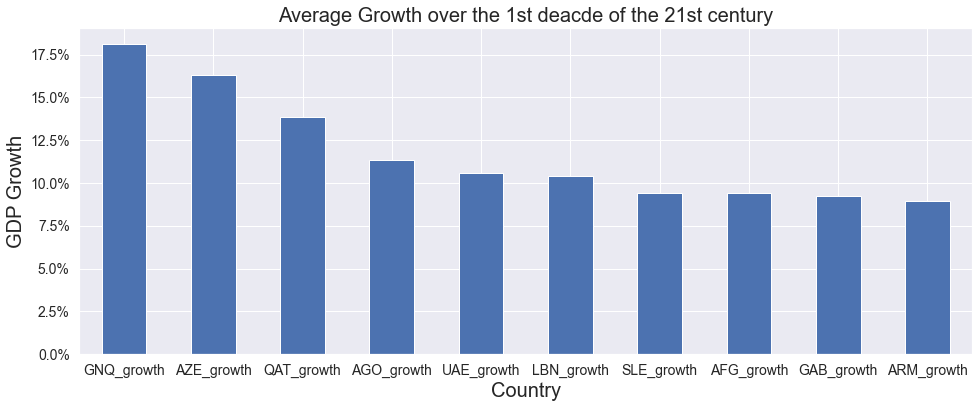

```python
sns.set(rc={'figure.figsize':(16,6)})
sns.set_style('darkgrid')
#
df= df_master_clean.loc[:,'GNQ_growth':'ARM_growth'].transpose()
df['avg_growth']= df.loc[:,'2000':'2009'].mean(axis=1)
ax= df['avg_growth'].plot(kind='bar')
#
pyplt.title('Average Growth over the 1st deacde of the 21st century', fontsize=20)
pyplt.xlabel('Country', fontsize=20)
pyplt.ylabel('GDP Growth', fontsize=20)
pyplt.xticks(rotation=0, fontsize=14)
pyplt.yticks(fontsize=14)
ax.yaxis.set_major_formatter(mplt.ticker.PercentFormatter());
```

> - `Equatorial Guinea` showing out-standing average growth with more than 18%, it seems that their efforts pay them back and they should keep this pace through the century.
> - As well, `Azerbaijan`, and `Qatar` showing strong performance, it seems that they utilize their natural resources income well in developing their countries.
> - `Sierra Leone`, `Afghanistan`, `Gabon`, and `Armenia` achieved almost the same growth with about 9%.
> - Surprisingly, four countries out of the ten are African countries which means that they started to get rid of their inner struggles and develop their countries instead. `Sierra Leone` especially experienced many bloody struggles.
> - Asia has a good representation in terms of four countries. Three are part of the Arab world namely `Qatar`, `United Arab Emirates`, and `Lebanon` respectively, in addition to the Central Asian countries `Afghanistan`.
> - Moreover, two of them are Caucasian/Eastern Europe countries `Azerbaijan`, and `Armenia`.

### What is the growth performance for each country over the mentioned years?

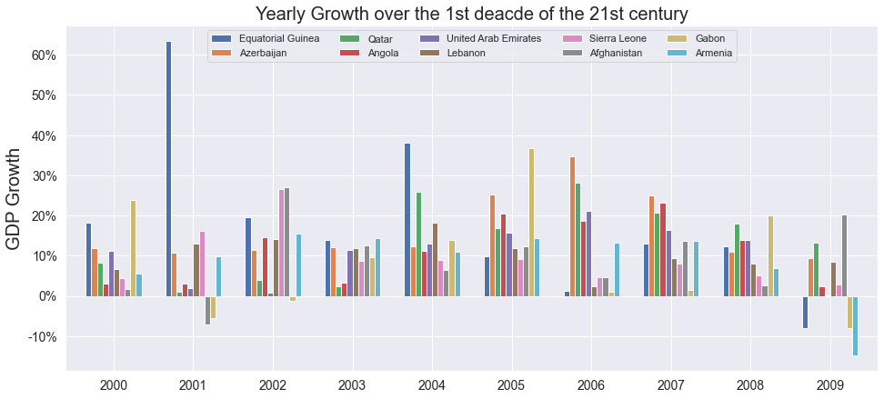

```python
sns.set(rc={'figure.figsize':(16,7)})
sns.set_style('darkgrid')
#
ax= df_master_clean.loc[:,'GNQ_growth':'ARM_growth'].plot(kind='bar', width=.7)
#
pyplt.title('Yearly Growth over the 1st deacde of the 21st century', fontsize=20)
pyplt.legend(labels= top10_contrs, loc="upper center", ncol=5)
pyplt.xlabel('', fontsize=20)
pyplt.ylabel('GDP Growth', fontsize=20)
pyplt.xticks(rotation=0, fontsize=14)
pyplt.yticks(fontsize=14)
ax.yaxis.set_major_formatter(mplt.ticker.PercentFormatter());
```

## 02. Top10 Countries GDP

Will explore the affect of **`GDP`** on two main metrics **`Income per person`**, and **`CO2 emission`**.

### How was the GDP trend for each country regardless its 10 years average growth?

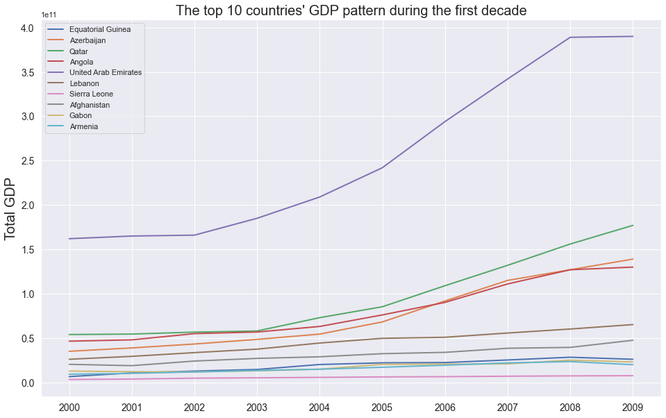

```python
sns.set(rc={'figure.figsize':(16,10)})
sns.set_style('darkgrid')
#
sns.lineplot(data= df_master_clean.loc[:,'GNQ_gdp':'ARM_gdp'], linewidth=2, dashes=False)
#
pyplt.legend(labels= top10_contrs)
pyplt.title('The top 10 countries\' GDP pattern during the first decade' , fontsize=20)
pyplt.xlabel('', fontsize=20)
pyplt.ylabel('Total GDP', fontsize=20)
pyplt.xticks(fontsize=14)
pyplt.yticks(fontsize=14);
```

> - `Qatar`, `Azerbaijan`, and `Angola` have the most optimistic GDP growth trend comparing to their initial GDP amount and to `UAE` which has GDP much higher than these countries. But, `UAE` also achieved robust growth; almost doubled its initial GDP.
> - While `UAE`, and `Angola` suffered from the world recession in 2008 as appears in their 2009 growth, `Qatar`, `Azerbaijan` succeeded to pass this crisis amazingly; keep their exponential growth trend.

## a) Income per person

### Which country's citizens felt the most income improvement through the decade?

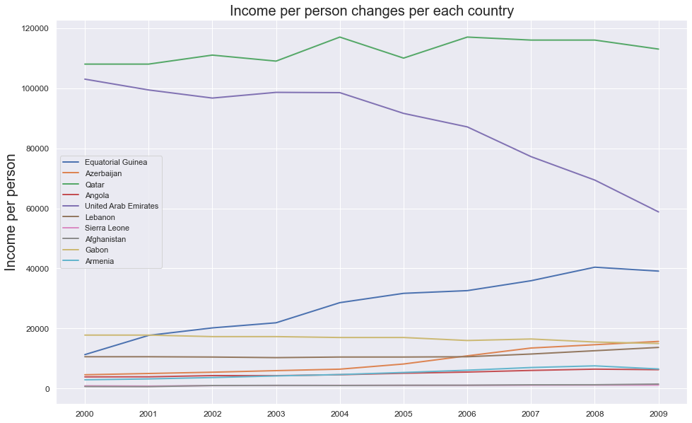

```python
sns.set(rc={'figure.figsize':(16,10)})
sns.set_style('darkgrid')
#
sns.lineplot(data= df_master_clean.loc[:,'GNQ_income':'ARM_income'], linewidth=2, dashes=False)
#
pyplt.legend(labels= top10_contrs)
pyplt.title('Income per person changes per each country', fontsize=20)
pyplt.xlabel('', fontsize=20)
pyplt.ylabel('Income per person', fontsize=20)
pyplt.xticks(fontsize=12)
pyplt.yticks(fontsize=12);
```

> - `Equatorial Guinea` citizens felt the highest positive impact of their country GDP growth followed by `Azerbaijan`, while `Gabon` citizens found the opposite.
> - Also, `Lebanon`, `Armenia`, and `Angola` peoples gained more wealth from their country's GDP growth.
> - While `Qatar` secured almost the same high level of wealth for its citizens, `UAE` nationals lost almost 50% of their income especially starting from 2004.

### What could be the relation between GDP rising and citizens' wealth generally?

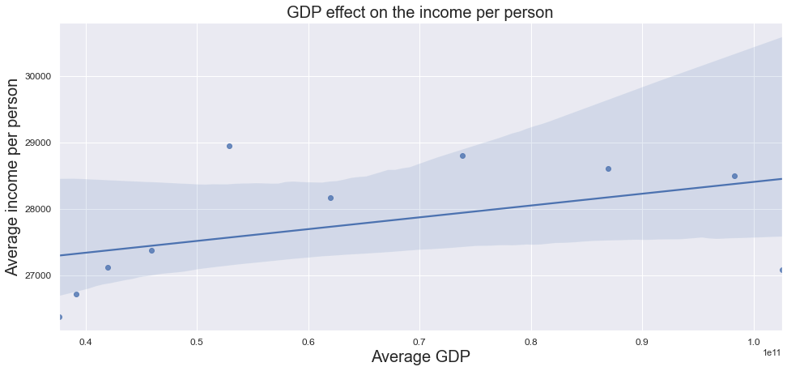

```python
sns.set(rc={'figure.figsize':(16,7)})
sns.set_style('darkgrid')
#
sns.regplot(x=df_master_clean.loc[:,'GNQ_gdp':'ARM_gdp'].mean(axis=1), y=df_master_clean.loc[:,'GNQ_income':'ARM_income'].mean(axis=1))
#
pyplt.title('GDP effect on the income per person', fontsize=20)
pyplt.xlabel('Average GDP', fontsize=20)
pyplt.ylabel('Average income per person', fontsize=20)
pyplt.xticks(fontsize=12)
pyplt.yticks(fontsize=12);
```

## b) CO2 emission

### Which country was the best in reducing its CO2 emission individually?

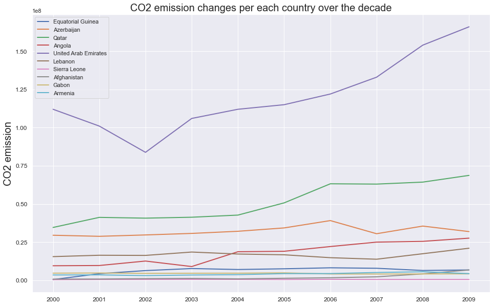

```python
sns.set(rc={'figure.figsize':(16,10)})
sns.set_style('darkgrid')
#
sns.lineplot(data= df_master_clean.loc[:,'GNQ_co2':'ARM_co2']*1000, linewidth=2, dashes=False)
#
pyplt.legend(labels= top10_contrs)
pyplt.title('CO2 emission changes per each country over the decade', fontsize=20)
pyplt.xlabel('', fontsize=16)
pyplt.ylabel('CO2 emission', fontsize=20)
pyplt.xticks(fontsize=12)
pyplt.yticks(fontsize=12);
```

### On average, how the GDP increasing affects CO2 Emission for the top 10 countries?

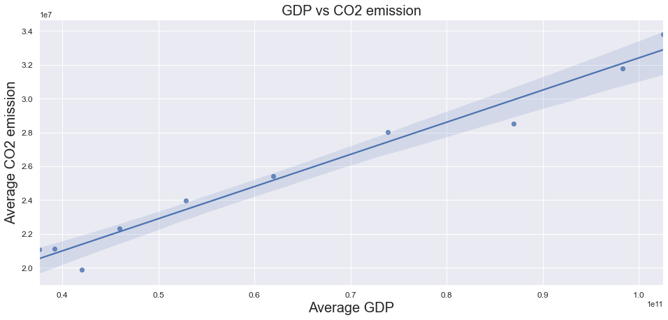

```python
sns.set(rc={'figure.figsize':(16,7)})
sns.set_style('darkgrid')
#
sns.regplot(x=df_master_clean.loc[:,'GNQ_gdp':'ARM_gdp'].mean(axis=1), y= df_master_clean.loc[:,'GNQ_co2':'ARM_co2'].mean(axis=1)*1000)
#
pyplt.title('GDP vs CO2 emission', fontsize=20)
pyplt.xlabel('Average GDP', fontsize=20)
pyplt.ylabel('Average CO2 emission', fontsize=20)
pyplt.xticks(fontsize=12)
pyplt.yticks(fontsize=12);
```

> - It seems that the mentioned countries didn't consider their duty to the environment in their development plan.
> - Whilst, so far, all numbers are very positive and implied a strong intention from the countries to make their people's lives better, they should also don't miss the negative human impact on our earth.

## 03. Education Expenditure

Will explore how this **`Education Expenditure`** metric interacted with countries development and its affect on the **`Human Development Index`**

### How the top 10 countries invested in educating their peoples?

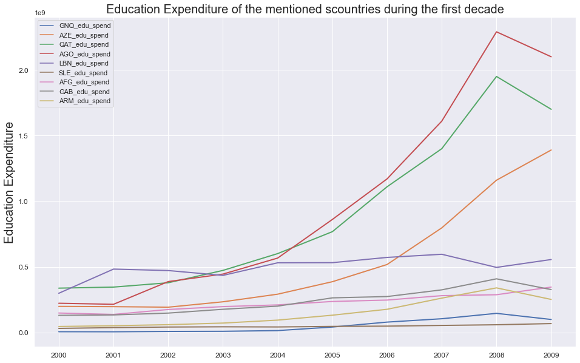

```python
sns.set(rc={'figure.figsize':(16,10)})
sns.set_style('darkgrid')
#
sns.lineplot(data= df_master_clean.loc[:,'GNQ_edu_spend':'ARM_edu_spend'], linewidth=2, dashes=False)
#
# pyplt.legend(labels= top10_contrs)
pyplt.title('Education Expenditure of the mentioned scountries during the first decade', fontsize=20)
pyplt.xlabel('', fontsize=16)
pyplt.ylabel('Education Expenditure', fontsize=20)
pyplt.xticks(fontsize=12)
pyplt.yticks(fontsize=12);
```

> - `Angola` shows superb interest in education, it doubled its budget ten times and reached its maximum in 2008, **Superb Performance**.
> - As well `Qatar`, and `Azerbaijan` invested a great bunch of money in their education sector.
> - While `Lebanon`, and `Sierra Leone` roughly moved around the same amount of education investment, `Afganistan`, `Equatorial Guinea`, `Gabon`, and `Armenia` showed strong desire to secure better education According to their capabilities.
> - It's notable here to mention that `UAE` not represented in this plot because there is no official data has been published either by `UAE` or any global organization.

## a) HDI

### How the education expenditure improved each country (HDI - Human Development Index)?

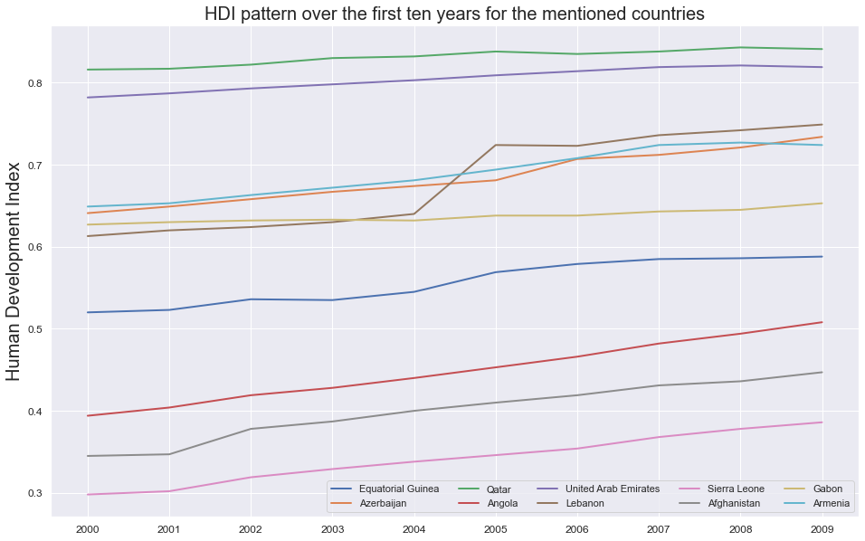

```python
sns.set(rc={'figure.figsize':(16,10)})
sns.set_style('darkgrid')
#
sns.lineplot(data= df_master_clean.loc[:,'GNQ_hdi':'ARM_hdi'], linewidth=2, dashes=False)
#
pyplt.legend(labels= top10_contrs, loc="lower right", ncol=5)
pyplt.title('HDI pattern over the first ten years for the mentioned countries', fontsize=20)
pyplt.xlabel('', fontsize=16)
pyplt.ylabel('Human Development Index', fontsize=20)
pyplt.xticks(fontsize=12)
pyplt.yticks(fontsize=12);
```

> - Distinctly, `Angola`, `Afghanistan`, `Sierra Leone` found what they worked for, superb evolution in this side.
> - Likewise, `Azerbaijan`, `Armenia`, and `Equatorial Guinea` achieved a higher level in this important metric.
> - `Qatar`, `UAE`, and `Gabon` would be ranked as the third-highest achieved countries with reasonable improvements.
> - Regarding `Lebanon`, as we didn't find official data related to it and we considered the average data shared by UNDP for the **Arab States** for the years **2000-2005**, it'll be hard to evaluate its actual evolution. However, as per the official data for the years **2005-2009**, `Lebanon` already at a good level in this metric.

### Summarized correlation between Education-Expenditure and (HDI - Human Development Index).

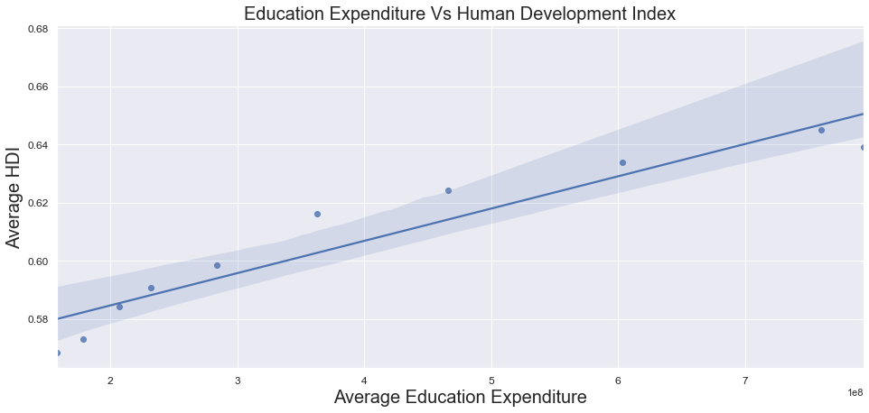

```python
sns.set(rc={'figure.figsize':(16,7)})
sns.set_style('darkgrid')
#
sns.regplot(x=df_master_clean.loc[:,'GNQ_edu_spend':'ARM_edu_spend'].mean(axis=1), y= df_master_clean.loc[:,'GNQ_hdi':'ARM_hdi'].mean(axis=1))
#
pyplt.title('Education Expenditure Vs Human Development Index', fontsize=20)
pyplt.xlabel('Average Education Expenditure', fontsize=20)
pyplt.ylabel('Average HDI', fontsize=20)
pyplt.xticks(fontsize=12)
pyplt.yticks(fontsize=12);
```

> - Undoubtedly, as much each country invests in educating nationals, as its peoples will become more educated and cultured and will push it further forward. Human is the most valuable free resources.

## 04. Health spending per person

Will investigate if the **top-10 countries** considered the **Health Expenditure** in their development plans and how this affect their **`Life Expectancy`**.

### How the countries considered their Health sector in their development plan?

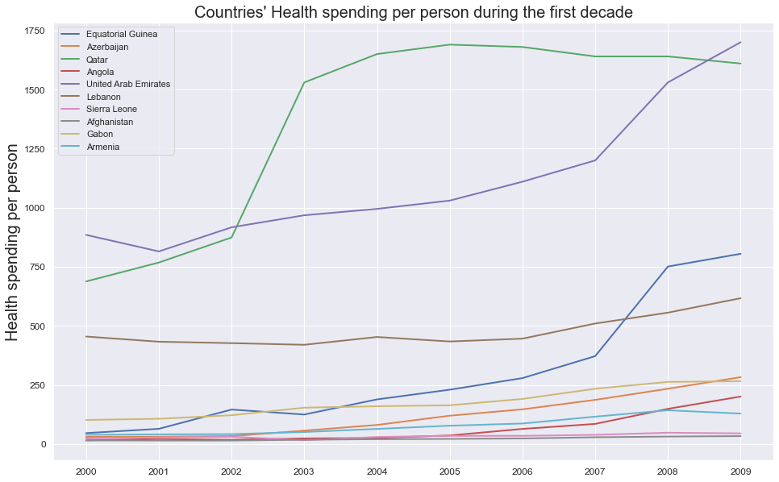

```python
sns.set(rc={'figure.figsize':(16,10)})
sns.set_style('darkgrid')
#
sns.lineplot(data= df_master_clean.loc[:,'GNQ_hlth_spend':'ARM_hlth_spend'], linewidth=2, dashes=False)
#
pyplt.legend(labels= top10_contrs)
pyplt.title('Countries\' Health spending per person during the first decade', fontsize=20)
pyplt.xlabel('', fontsize=16)
pyplt.ylabel('Health spending per person', fontsize=20)
pyplt.xticks(fontsize=12)
pyplt.yticks(fontsize=12);
```

## a) Life expectancy

### Which country got the most benefits from its Health Expenditures in terms of "Life Expectancy"?

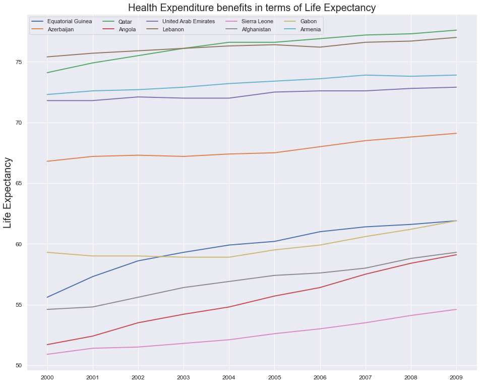

```python
sns.set(rc={'figure.figsize':(16,13)})
sns.set_style('darkgrid')
#
sns.lineplot(data= df_master_clean.loc[:,'GNQ_life_expct':'ARM_life_expct'], linewidth=2, dashes=False)
#
pyplt.legend(labels= top10_contrs, loc="upper left", ncol=5)
pyplt.title('Health Expenditure benefits in terms of Life Expectancy', fontsize=20)
pyplt.xlabel('', fontsize=16)
pyplt.ylabel('Life Expectancy', fontsize=20)
pyplt.xticks(fontsize=12)
pyplt.yticks(fontsize=12);
```

> - Citizens of `Angola`, `Equatorial Guinea`, and `Afghanistan` found the best impact and felt better health care as a result of their countries' efforts in the health sector.
> - `Sierra Leone`, `Azerbaijan`, and `Qatar` come in the second place of the most benefited countries form their national health investment.
> - Furthermore, there is a notable gap that separates the ten countries into two separate groups at which between **63-69**. Where, `Equatorial Guinea`, `Gabon`, `Afghanistan`, `Angola`, and `Sierra Leone` were always 63 years or less in their people's life expectancy. Meanwhile, `Qatar`, `Lebanon`, `Armenia`, `UAE`, and `Azerbaijan` were always 63 years or higher in their people's life expectancy.

### Simple representation of the "Health-Expenditure" effect on the "Life-Expectancy" metric.

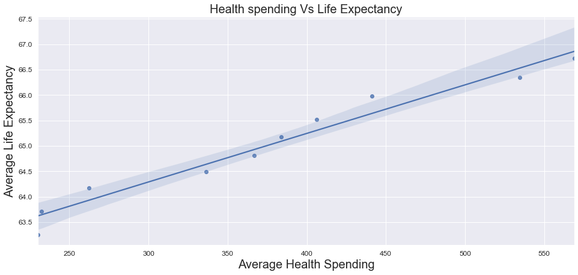

```python
sns.set(rc={'figure.figsize':(16,7)})
sns.set_style('darkgrid')
#
sns.regplot(x=df_master_clean.loc[:,'GNQ_hlth_spend':'ARM_hlth_spend'].mean(axis=1), y= df_master_clean.loc[:,'GNQ_life_expct':'ARM_life_expct'].mean(axis=1))
#
pyplt.title('Health spending Vs Life Expectancy', fontsize=20)
pyplt.xlabel('Average Health Spending', fontsize=20)
pyplt.ylabel('Average Life Expectancy', fontsize=20)
pyplt.xticks(fontsize=12)
pyplt.yticks(fontsize=12);
```

> - Strong positive correlation between **Health spending per person** and nationals' **Life Expectancy**. It's reasonable and common sense, as long country government dedicate more efforts and budget to improve peoples' health services as citizens will be more probable to live for more years with good health which will reward them back with more economic advancement and GDP growth.